# multiple-linear-regression

## Multiple Linear Regression

Linear Regression is a useful tool for predicting a quantitative response.

We have an input vector $X^T = (X_1, X_2,...,X_p)$, and want to predict a real-valued output $Y$. The linear regression model has the form

#### $f(x) = \beta_0 + \sum_{j=1}^p X_j \beta_j$.

The linear model either assumes that the regression function $E(Y|X)$ is linear, or that the linear model is a reasonable approximation.Here the $\beta_j$'s are unknown parameters or coefficients, and the variables $X_j$ can come from different sources. No matter the source of $X_j$, the model is linear in the parameters.

**Simple Linear Regression**:

##### $$Y = \beta_0 + \beta_1 X + \epsilon$$

**Multiple Linear Regression**:

##### $$Y = \beta_0 + \beta_1 X_1 + \beta_2 X_2 +...+ \beta_p X_p + \epsilon$$

##### $$sales = \beta_0 + \beta_1 \times TV + \beta_2 \times radio + \beta_3 \times newspaper + \epsilon$$

### Task 1: Importing Libraries

```python
import pandas as pd
import numpy as np
import seaborn as sns
from scipy.stats import skew
%matplotlib inline
```

```python
import matplotlib.pyplot as plt
plt.style.use("ggplot")
plt.rcParams['figure.figsize'] = (12, 8)
```

### Task 2: Load the Data

The adverstiting dataset captures sales revenue generated with respect to advertisement spends across multiple channles like radio, tv and newspaper.

```python
advert =  pd.read_csv("Advertising.csv")
advert.head()
```

|  | TV | radio | newspaper | sales |
| --- | --- | --- | --- | --- |
| 0 | 230.1 | 37.8 | 69.2 | 22.1 |
| 1 | 44.5 | 39.3 | 45.1 | 10.4 |
| 2 | 17.2 | 45.9 | 69.3 | 9.3 |
| 3 | 151.5 | 41.3 | 58.5 | 18.5 |
| 4 | 180.8 | 10.8 | 58.4 | 12.9 |

```python
advert.info()
```

```
<class 'pandas.core.frame.DataFrame'>
RangeIndex: 200 entries, 0 to 199
Data columns (total 4 columns):
TV           200 non-null float64
radio        200 non-null float64
newspaper    200 non-null float64
sales        200 non-null float64
dtypes: float64(4)
memory usage: 6.3 KB
```

### Task 3: Relationship between Features and Response

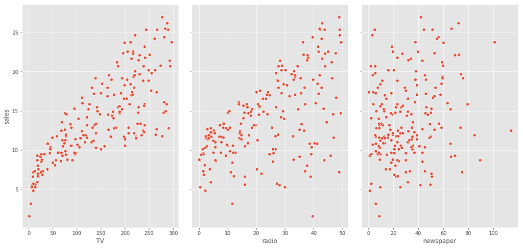

```python
sns.pairplot(advert, x_vars=['TV', 'radio', 'newspaper'], y_vars='sales', height=7,
            aspect=0.7)
```

### Task 4: Multiple Linear Regression - Estimating Coefficients

```python
from sklearn.linear_model import LinearRegression
X = advert[['TV', 'radio', 'newspaper']]
y = advert.sales

lm1 = LinearRegression()
lm1.fit(X,y)

print(lm1.intercept_)
print(lm1.coef_)
```

```
2.9388893694594085
[ 0.04576465  0.18853002 -0.00103749]
```

```python
list(zip(['TV', 'radio', 'newspaper'], lm1.coef_))
```

```
[('TV', 0.0457646454553976),
 ('radio', 0.18853001691820453),
 ('newspaper', -0.00103749304247629)]
```

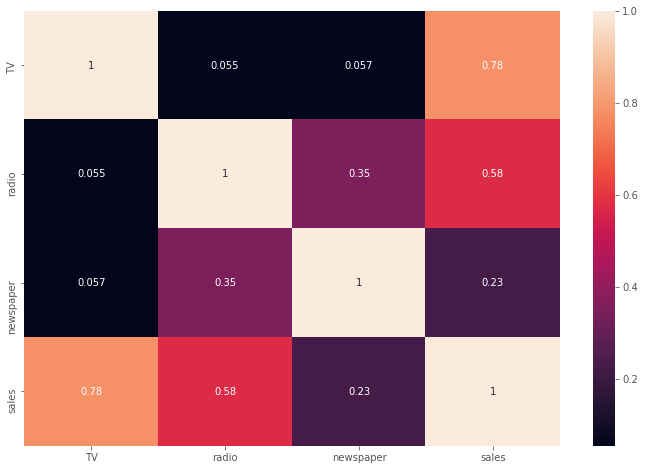

```python
sns.heatmap(advert.corr(), annot=True)
```

### Task 5: Feature Selection

```python
from sklearn.metrics import r2_score
lm2 = LinearRegression().fit(X[['TV', 'radio']] , y)
lm2_pred = lm2.predict(X[['TV', 'radio']])

print("R^2", r2_score(y,lm2_pred))
```

```
R^2 0.8971942610828957
```

```python
lm3 = LinearRegression().fit(X[['TV', 'radio', 'newspaper']] , y)
lm3_pred = lm3.predict(X[['TV', 'radio','newspaper']])

print("R^2", r2_score(y,lm3_pred))
```

```
R^2 0.8972106381789522
```

### Task 6: Model Evaluation Using Train/Test Split and Metrics

**Mean Absolute Error** (MAE) is the mean of the absolute value of the errors:

##### $$\frac{1}{n}\sum_{i=1}^{n} \left |y_i - \hat{y_i} \right |$$

**Mean Squared Error** (MSE) is the mean of the squared errors:

Let's use train/test split with RMSE to see whether newspaper should be kept in the model:

```python
from sklearn.model_selection import train_test_split
from sklearn.metrics import mean_squared_error

X =  advert[['TV', 'radio', 'newspaper']]
y = advert.sales

X_train, X_test, y_train, y_test = train_test_split(X,y, random_state=1)

lm4 = LinearRegression().fit(X_train, y_train)
lm4_pred = lm4.predict(X_test)

print("RSME:", np.sqrt(mean_squared_error(y_test, lm4_pred)))
print("R^2:", r2_score(y_test, lm4_pred))
```

```
RSME: 1.4046514230328953
R^2: 0.9156213613792232
```

```python
X =  advert[['TV', 'radio']]
y = advert.sales

X_train, X_test, y_train, y_test = train_test_split(X,y, random_state=1)

lm5 = LinearRegression().fit(X_train, y_train)
lm5_pred = lm5.predict(X_test)

print("RSME:", np.sqrt(mean_squared_error(y_test, lm5_pred)))
print("R^2:", r2_score(y_test, lm5_pred))
```

```
RSME: 1.3879034699382888
R^2: 0.9176214942248908
```

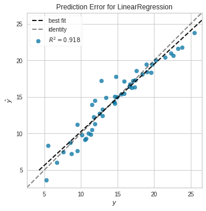

```python
from yellowbrick.regressor import PredictionError, ResidualsPlot

visualizer = PredictionError(lm5).fit(X_train,y_train)
visualizer.score(X_test, y_test)
visualizer.poof()

#multiple regression line
```

### Task 7: Interaction Effect (Synergy)

```python
advert['interaction'] = advert['TV'] * advert['radio']

X= advert[['TV', 'radio', 'interaction']]
y= advert.sales

X_train, X_test, y_train, y_test = train_test_split(X,y, random_state=1)

lm6 = LinearRegression().fit(X_train, y_train)
lm6_pred = lm6.predict(X_test)

print("RSME:", np.sqrt(mean_squared_error(y_test, lm6_pred)))
print("R^2:", r2_score(y_test, lm6_pred))
```

```
RSME: 0.7011871137164326
R^2: 0.9789736814681261
```

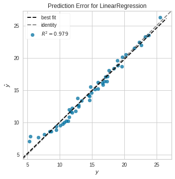

```python
visualizer = PredictionError(lm6).fit(X_train,y_train)
visualizer.score(X_test, y_test)
visualizer.poof()

#multiple regression line
```